# Intro to Data Science - Group1 Project1

Group 1

2023-10-14

#Question1

```
## tibble [4,024 × 6] (S3: tbl_df/tbl/data.frame)
##  $ Date    : Date[1:4024], format: "2007-10-01" "2007-10-02" ...
##  $ Price   : num [1:4024] 2117 2116 2103 2106 2150 ...
##  $ Open    : num [1:4024] 2093 2116 2108 2107 2123 ...
##  $ High    : num [1:4024] 2121 2117 2117 2108 2152 ...
##  $ Low     : num [1:4024] 2093 2104 2095 2089 2118 ...
##  $ Change %: chr [1:4024] "1.24%" "-0.05%" "-0.61%" "0.12%" ...
```

```
## tibble [4,165 × 6] (S3: tbl_df/tbl/data.frame)
##  $ Date    : Date[1:4165], format: "2007-10-01" "2007-10-02" ...
##  $ Price   : num [1:4165] 77.9 78.3 78.6 78.5 78.3 ...
##  $ Open    : num [1:4165] 77.8 78 78.3 78.7 78.5 ...
##  $ High    : num [1:4165] 78 78.4 78.6 78.7 78.8 ...
##  $ Low     : num [1:4165] 77.7 77.9 78.1 78.3 78.2 ...
##  $ Change %: chr [1:4165] "0.23%" "0.51%" "0.34%" "-0.11%" ...
```

```
## tibble [4,024 × 6] (S3: tbl_df/tbl/data.frame)
##  $ Date    : Date[1:4024], format: "2007-10-01" "2007-10-02" ...
##  $ Price   : num [1:4024] 1547 1547 1540 1543 1558 ...
##  $ Open    : num [1:4024] 1527 1547 1546 1540 1544 ...
##  $ High    : num [1:4024] 1549 1548 1546 1544 1562 ...
##  $ Low     : num [1:4024] 1527 1540 1536 1538 1544 ...
##  $ Change %: chr [1:4024] "1.33%" "-0.03%" "-0.46%" "0.21%" ...
```

# 1- Histograms

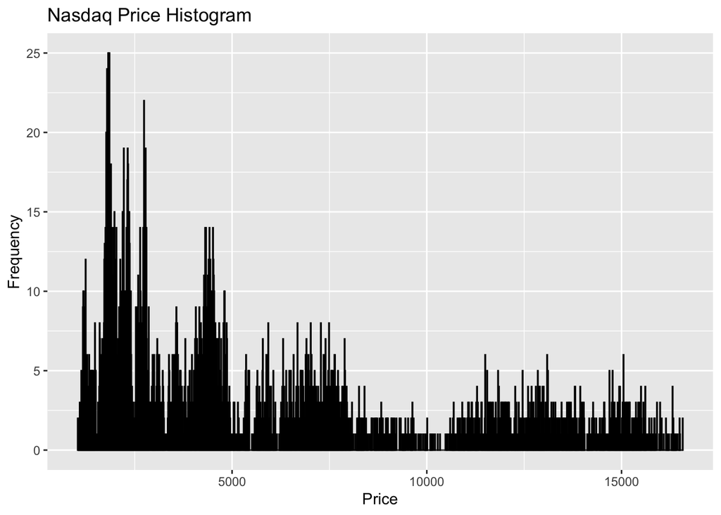

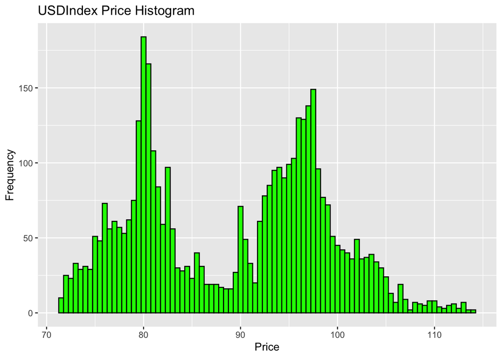

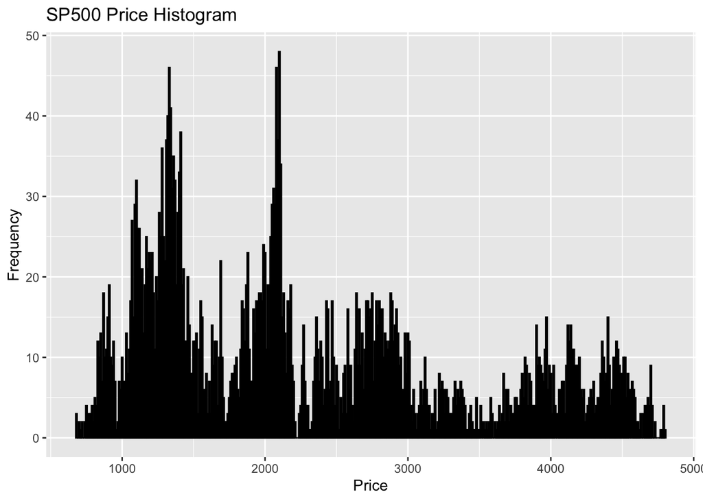

# 2- Boxplot for each variables

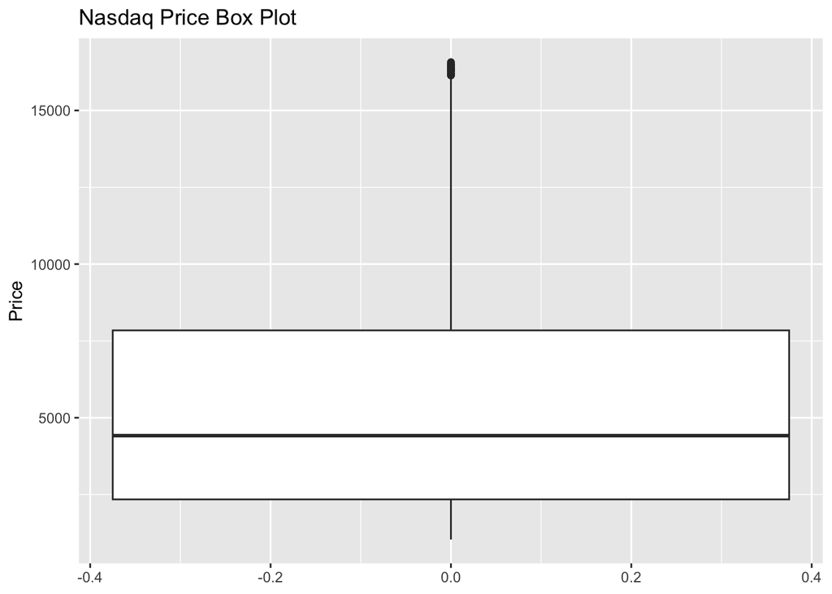

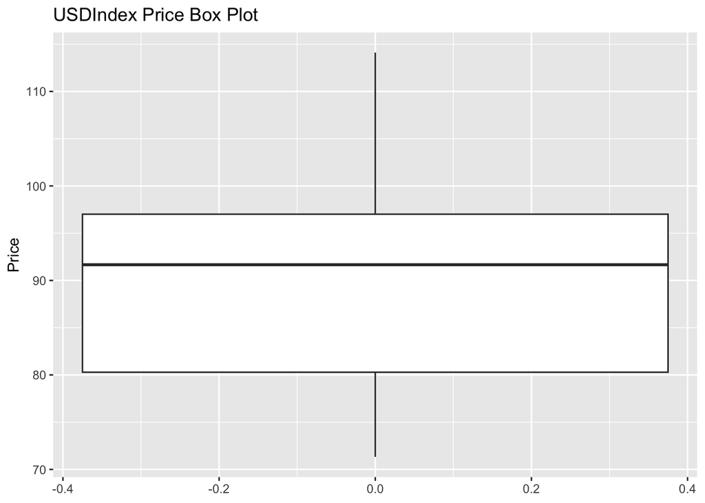

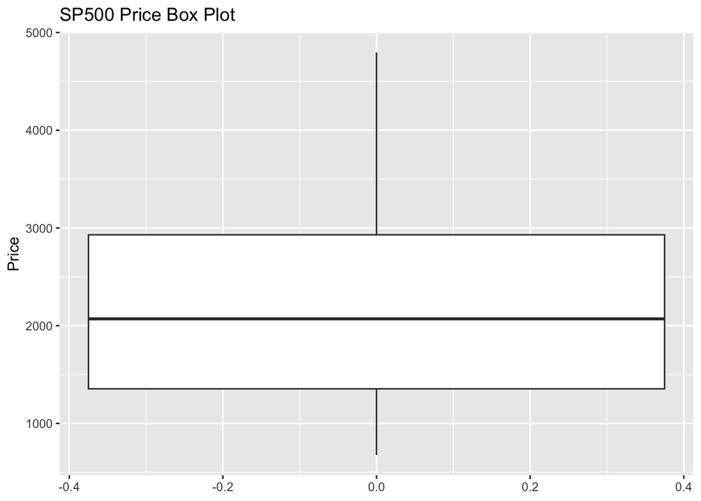

Accoording to these boxplots, we only have outliers with our Nasdaq variable.

# 3- Merge the data frames to filter USDIndex by Nasdaq’s dates

```
## 'data.frame':    4024 obs. of  11 variables:
##  $ Date      : Date, format: "2007-10-01" "2007-10-02" ...
##  $ Price.x   : num  2117 2116 2103 2106 2150 ...
##  $ Open.x    : num  2093 2116 2108 2107 2123 ...
##  $ High.x    : num  2121 2117 2117 2108 2152 ...
##  $ Low.x     : num  2093 2104 2095 2089 2118 ...
##  $ Change %.x: chr  "1.24%" "-0.05%" "-0.61%" "0.12%" ...
##  $ Price.y   : num  77.9 78.3 78.6 78.5 78.3 ...
##  $ Open.y    : num  77.8 78 78.3 78.7 78.5 ...
##  $ High.y    : num  78 78.4 78.6 78.7 78.8 ...
##  $ Low.y     : num  77.7 77.9 78.1 78.3 78.2 ...
##  $ Change %.y: chr  "0.23%" "0.51%" "0.34%" "-0.11%" ...
```

# 4- Correlation between Nasdaq & US Dollar price Index

```
## Pearson Correlation Test : 0.7124617
```

A correlation coefficient of 0.71246 between the US Dollar Index and the Nasdaq Index Price suggests a relatively strong positive linear relationship between these two variables. Meaning that when the US Dollar Index increases, the Nasdaq Index tends to increase as well.

# 5- Line Plots

# a- Nasdaq Index & US Dollar Index

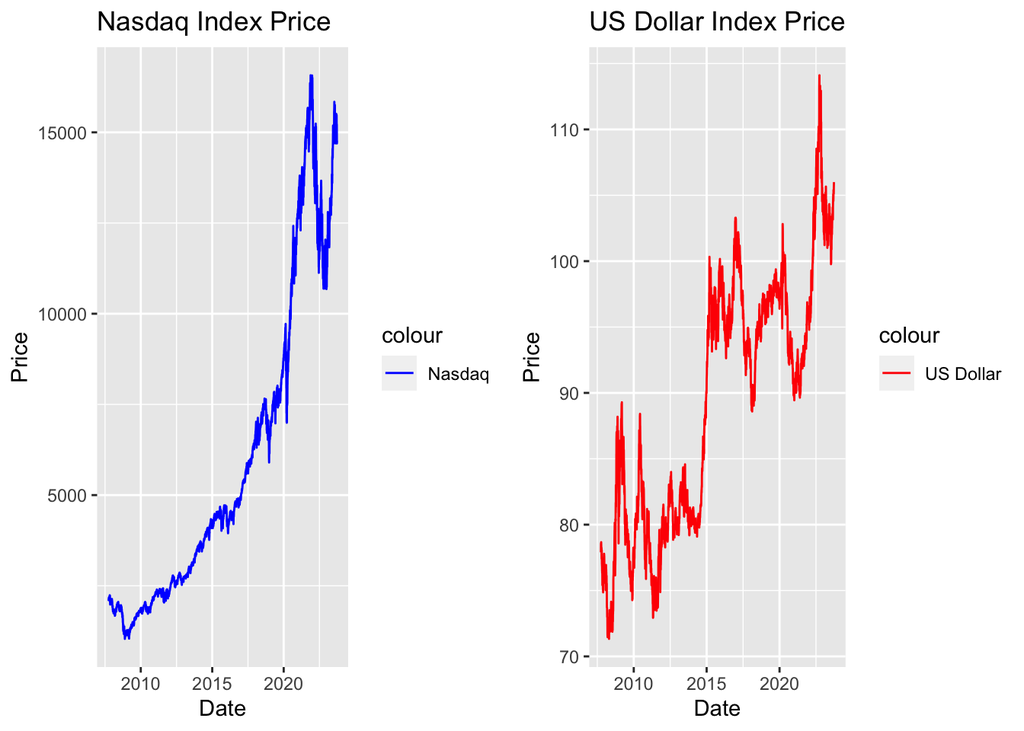

# b- Nasdaq and S&P 500

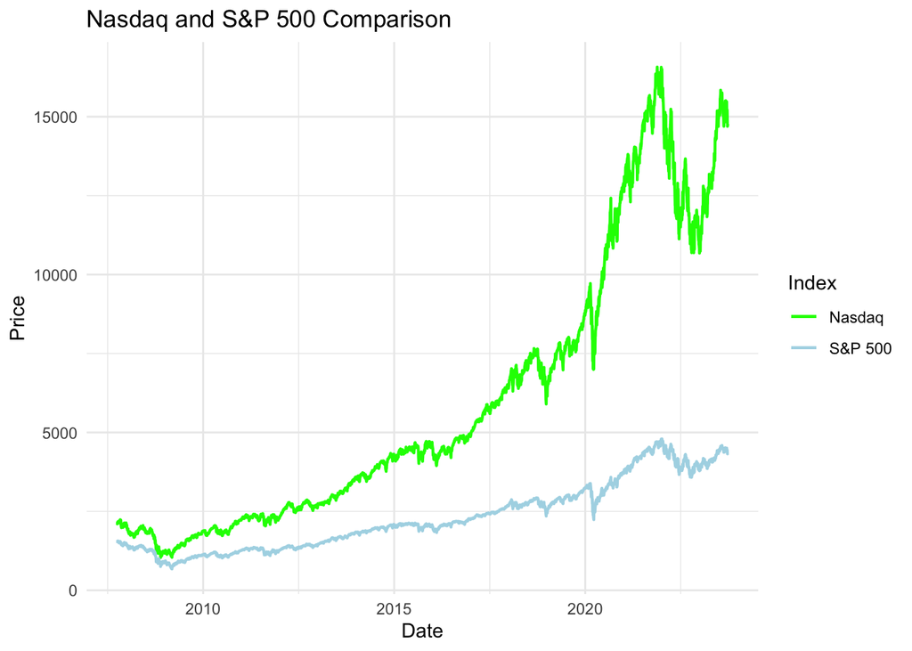

From this comparison line plot, we can infer that Nasdaq and S&P500 have a positive relationship. Even though subtle, we can follow the movement of both variables across the chosen time frame and note that in every increase in S&P500 Index, there is also a quite significant increase in Nasdq Index.

# 6- Scatter plot

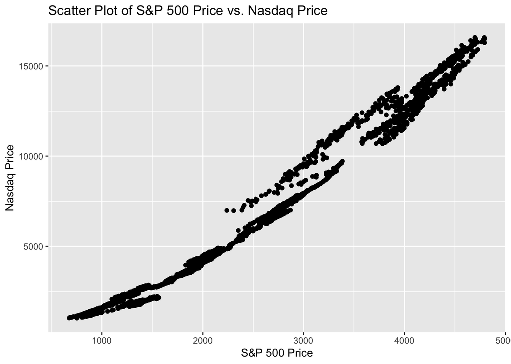

With this scatter plot, we can better identify the positive relationship betwwen S$P 500 Index and Nasdaq Index. we can infer that with every increase in Nasdaq, we can expect S&P 500 to increase as well.